# 03 — K562 CRISPRi perturbation responses

# Audit and design

The Part 1 12,000-cell subset retains perturbation diversity but has too few cells per target for detailed comparisons. This notebook loads that object, audits counts, then creates a separate seeded sample from the unchanged public raw H5AD. It uses the Part 1 QC thresholds and retains only targets with at least 100 post-QC sampled cells. The threshold is an exploratory minimum for stable summaries, not a substitute for biological replication.

```r
library(Seurat)
library(anndataR)
library(Matrix)
library(dplyr)
library(ggplot2)
library(tibble)
```

```r
part1 <- readRDS("data/processed/02_k562_clustered_seurat.rds")
stopifnot("gene" %in% colnames(part1[[]]))
part1_counts <- as.data.frame(table(as.character(part1$gene)))
names(part1_counts) <- c("perturbation", "n_cells")
part1_counts <- arrange(part1_counts, desc(n_cells))
head(part1_counts, 15)
```

```
##     perturbation n_cells
## 1  non-targeting      76
## 2           RPL3      13
## 3           RRM2      13
## 4          KIF11      11
## 5          NCBP2      11
## 6          SSRP1      11
## 7           TSR2      11
## 8          XRCC1      11
## 9         DONSON      10
## 10         KPNB1      10
## 11          NUF2      10
## 12         NUP54      10
## 13         PMPCB      10
## 14      PRELID3B      10
## 15          RPA1      10
```

```r
cat("Target labels with at least 100 cells:", sum(part1_counts$n_cells >= 100 & part1_counts$perturbation != "non-targeting"), "\n")
```

```
## Target labels with at least 100 cells: 0
```

```r
control_labels <- unique(as.character(part1$gene))[grepl("non.?target|negative.?control|^ntc$", unique(as.character(part1$gene)), ignore.case=TRUE)]
print(control_labels)
```

```
## [1] "non-targeting"
```

```r
stopifnot(identical(control_labels, "non-targeting"))
CONTROL_LABEL <- control_labels[[1]]
rm(part1)
gc()
```

```
##           used  (Mb) gc trigger   (Mb)  max used   (Mb)
## Ncells 3648621 194.9    5317617  284.0   5317617  284.0
## Vcells 6339056  48.4  167811344 1280.3 177219502 1352.1
```

### Interpretation

The broad 12,000-cell subset has only about five cells per targeting label, and none meet the 100-cell threshold. Its breadth is useful for coverage but insufficient for detailed target-level comparisons. Metadata identifies one control label, `non-targeting`.

# Supplemental sampling from the public raw H5AD

The following Python chunk reads metadata from the raw file, selects the 12 most represented targeting labels, samples up to 250 cells per target and 500 controls with seed 42, and applies the Part 1 count, feature, and mitochondrial QC limits. It writes a sparse, modern H5AD without modifying the raw file. Selection by source abundance favors common perturbations; results do not represent all 2,058 targets.

```r
reticulate::use_python("C:/Python314/python.exe", required=TRUE)
```

```python
import anndata as ad
import numpy as np
import pandas as pd
from scipy import sparse
from pathlib import Path

raw = ad.read_h5ad("data/raw/K562_essential_raw_singlecell_01.h5ad", backed="r")
label_counts = raw.obs["gene"].value_counts()
assert "non-targeting" in label_counts.index
targets = label_counts.drop("non-targeting").head(12).index.tolist()
rng = np.random.default_rng(42)
chosen = []
for label in ["non-targeting"] + targets:
    positions = np.flatnonzero(raw.obs["gene"].to_numpy() == label)
    chosen.extend(rng.choice(positions, min(len(positions), 500 if label == "non-targeting" else 250), replace=False))
chosen = np.sort(np.asarray(chosen))
matrix = np.asarray(raw.X[chosen, :])
names = raw.var["gene_name"].astype(str).to_numpy()
mt = np.char.startswith(names.astype(str), "MT-")
n_count = matrix.sum(axis=1)
n_feature = np.count_nonzero(matrix, axis=1)
mt_percent = np.divide(100 * matrix[:, mt].sum(axis=1), n_count, out=np.zeros_like(n_count), where=n_count > 0)
qc = pd.read_csv("results/01_qc_report.csv").iloc[0]
keep = ((n_feature >= qc.feature_lower) & (n_feature <= qc.feature_upper) &
        (n_count >= qc.count_lower) & (n_count <= qc.count_upper) &
        (mt_percent <= qc.mt_max_percent))
meta = raw.obs.iloc[chosen[keep]].copy()
meta["nCount_RNA"] = n_count[keep]
meta["nFeature_RNA"] = n_feature[keep]
meta["percent.mt"] = mt_percent[keep]
var = raw.var.copy()
var["ensembl_id"] = var.index.astype(str)
seen, symbols = {}, []
for name in names:
    count = seen.get(name, 0)
    symbols.append(name if count == 0 else f"{name}_{count}")
    seen[name] = count + 1
var.index = symbols
sample = ad.AnnData(X=sparse.csr_matrix(matrix[keep, :]), obs=meta, var=var)
Path("data/processed").mkdir(exist_ok=True)
sample.write_h5ad("data/processed/03_k562_powered_sample.h5ad", compression="gzip")
pd.DataFrame({"target": targets, "source_cells": label_counts.loc[targets].to_numpy()}).to_csv("results/03_source_target_counts.csv", index=False)
print("Sample shape:", sample.shape, "control:", (sample.obs.gene == "non-targeting").sum())
```

```
## Sample shape: (3458, 8563) control: 493
```

```python
print(sample.obs.gene.value_counts().to_string())
```

[output not shown]

[output cut: 2004 more lines]

[output not shown]

```python
raw.file.close()
```

```r
adata <- read_h5ad("data/processed/03_k562_powered_sample.h5ad")
counts <- t(adata$X)
rownames(counts) <- rownames(adata$var)
colnames(counts) <- rownames(adata$obs)
meta <- as.data.frame(adata$obs)
rownames(meta) <- colnames(counts)
obj <- CreateSeuratObject(counts=counts, meta.data=meta, project="K562_CRISPRi_Part2")
MIN_CELLS <- 100L
cell_counts <- as.data.frame(table(as.character(obj$gene)))
names(cell_counts) <- c("perturbation", "n_cells")
cell_counts <- arrange(cell_counts, desc(n_cells))
eligible <- cell_counts |> filter(perturbation != CONTROL_LABEL, n_cells >= MIN_CELLS) |> pull(perturbation) |> as.character()
stopifnot(length(eligible) >= 4, cell_counts$n_cells[cell_counts$perturbation == CONTROL_LABEL] >= MIN_CELLS)
print(cell_counts)
```

```
##     perturbation n_cells
## 1  non-targeting     493
## 2           BUB1     249
## 3          KIF11     249
## 4         DONSON     248
## 5         NUP205     248
## 6           RPL3     248
## 7           GAB2     247
## 8           RRM2     247
## 9          CHMP6     246
## 10         NCBP2     246
## 11       SLC39A9     246
## 12         SNX15     246
## 13         CPSF3     245
```

```r
write.csv(cell_counts, "results/03_powered_cell_counts.csv", row.names=FALSE)
```

### Interpretation

The focused cohort retains 12 targets with 245–249 cells each and 493 non-targeting controls after the Part 1 QC limits. This provides greater within-cohort descriptive precision, but the 12 targets were selected by source abundance and do not represent all 2,058 labels or biological replicates.

# Direct target expression

```r
obj <- NormalizeData(obj, verbose=FALSE)
norm <- GetAssayData(obj, assay="RNA", layer="data")
kd <- lapply(eligible, function(target) {
  target_cells <- which(obj$gene == target)
  ctrl_cells <- which(obj$gene == CONTROL_LABEL)
  if (!(target %in% rownames(obj))) return(data.frame(target=target, target_present=FALSE, n_target=length(target_cells), n_control=length(ctrl_cells), mean_target=NA_real_, mean_control=NA_real_, detection_target=NA_real_, detection_control=NA_real_, delta_mean_log=NA_real_))
  target_values <- as.numeric(norm[target, target_cells])
  ctrl_values <- as.numeric(norm[target, ctrl_cells])
  a <- mean(target_values)
  b <- mean(ctrl_values)
  data.frame(target=target, target_present=TRUE, n_target=length(target_cells), n_control=length(ctrl_cells), mean_target=a, mean_control=b, detection_target=mean(target_values>0), detection_control=mean(ctrl_values>0), delta_mean_log=a-b)
}) |> bind_rows() |> arrange(delta_mean_log)
print(kd)
```

```
##     target target_present n_target n_control mean_target mean_control
## 1     RPL3           TRUE      248       493  3.00338040   3.44117183
## 2     BUB1           TRUE      249       493  0.09647232   0.50142586
## 3    NCBP2           TRUE      246       493  0.18311562   0.48701612
## 4    CPSF3           TRUE      245       493  0.04864903   0.33778804
## 5   DONSON           TRUE      248       493  0.02893571   0.29404423
## 6     RRM2           TRUE      247       493  0.40708299   0.58629940
## 7    KIF11           TRUE      249       493  0.29348906   0.42320138
## 8   NUP205           TRUE      248       493  0.32720214   0.42304534
## 9  SLC39A9           TRUE      246       493  0.01458158   0.10251877
## 10   CHMP6           TRUE      246       493  0.00000000   0.07746531
## 11   SNX15           TRUE      246       493  0.08346606   0.14139983
## 12    GAB2           TRUE      247       493  0.03803883   0.09392332
##    detection_target detection_control delta_mean_log
## 1        0.99596774         1.0000000    -0.43779142
## 2        0.15662651         0.6186613    -0.40495353
## 3        0.26422764         0.6288032    -0.30390050
## 4        0.08163265         0.5172414    -0.28913901
## 5        0.05241935         0.4503043    -0.26510853
## 6        0.49392713         0.6916836    -0.17921641
## 7        0.42570281         0.5618661    -0.12971232
## 8        0.48387097         0.6024341    -0.09584321
## 9        0.02439024         0.1784990    -0.08793719
## 10       0.00000000         0.1399594    -0.07746531
## 11       0.15853659         0.2474645    -0.05793376
## 12       0.06477733         0.1703854    -0.05588448
```

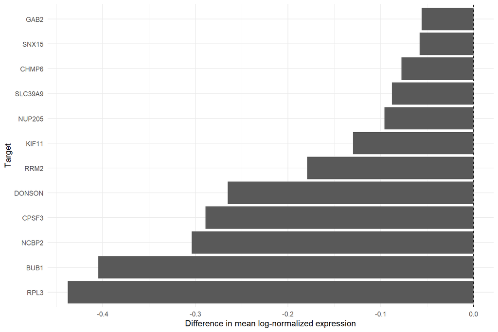

```r
write.csv(kd, "results/03_target_knockdown.csv", row.names=FALSE)
ggplot(kd, aes(x=reorder(target, delta_mean_log), y=delta_mean_log)) + geom_col() + coord_flip() +
  geom_hline(yintercept=0, linetype=2) + labs(x="Target", y="Difference in mean log-normalized expression") + theme_minimal()
```

### Key finding

RPL3 has the largest negative mean log-normalized target-expression difference (−0.438) among the 12 tested targets. Negative differences are consistent with target transcript reduction; detection fractions show when low expression limits interpretation. These cell-level summaries do not measure editing efficiency or provide biological-replicate evidence.

# Exploratory cell-level DE

Cell-level Wilcoxon tests compare cells within this public experiment. Cells are not independent biological replicates; adjusted p-values are exploratory and do not support replicate-aware inference.

```r
Idents(obj) <- "gene"
representative <- head(eligible, 4)
de_tables <- lapply(representative, function(target) {
  FindMarkers(obj, ident.1=target, ident.2=CONTROL_LABEL, test.use="wilcox", logfc.threshold=0, min.pct=0) |>
    rownames_to_column("gene") |>
    mutate(perturbation=target, significant=p_val_adj < 0.05 & abs(avg_log2FC) >= 0.5)
})
de <- bind_rows(de_tables)
de_summary <- de |> group_by(perturbation) |>
  summarise(n_tested=n(), n_exploratory_hits=sum(significant, na.rm=TRUE), .groups="drop")
print(de_summary)
```

```
## # A tibble: 4 x 3
##   perturbation n_tested n_exploratory_hits
##   <chr>           <int>              <int>
## 1 BUB1             8563                  2
## 2 DONSON           8563                 94
## 3 KIF11            8563                  0
## 4 NUP205           8563                  0
```

```r
print(de |> group_by(perturbation) |> slice_min(p_val_adj, n=5, with_ties=FALSE))
```

```
## # A tibble: 20 x 8
## # Groups:   perturbation [4]
##    gene          p_val avg_log2FC pct.1 pct.2 p_val_adj perturbation significant
##    <chr>         <dbl>      <dbl> <dbl> <dbl>     <dbl> <chr>        <lgl>
##  1 BUB1       1.35e-33    -2.53   0.157 0.619  1.16e-29 BUB1         TRUE
##  2 TMEM184C   2.17e- 7    -2.22   0.036 0.168  1.86e- 3 BUB1         TRUE
##  3 LGALS1     1.26e- 5    -0.679  0.301 0.465  1.08e- 1 BUB1         FALSE
##  4 AKAP10     2.97e- 5    -1.46   0.044 0.148  2.54e- 1 BUB1         FALSE
##  5 SETD9      3.39e- 5    -0.996  0.12  0.252  2.90e- 1 BUB1         FALSE
##  6 ALAS2      0            2.15   0.552 0.189  0        DONSON       TRUE
##  7 HEMGN      0            1.53   0.609 0.327  0        DONSON       TRUE
##  8 AC016629.2 0            2.95   0.327 0.051  0        DONSON       TRUE
##  9 BLVRB      0            1.56   0.956 0.724  0        DONSON       TRUE
## 10 MYL4       0            0.928  0.94  0.856  0        DONSON       TRUE
## 11 UBE2D1     8.72e- 5     0.807  0.329 0.197  7.46e- 1 KIF11        FALSE
## 12 KIF11      9.83e- 5    -0.589  0.426 0.562  8.41e- 1 KIF11        FALSE
## 13 TSEN34     2.23e- 4    -0.541  0.345 0.473  1   e+ 0 KIF11        FALSE
## 14 EEF1A1     5.29e- 4    -0.0990 1     1      1   e+ 0 KIF11        FALSE
## 15 FAHD2B     5.58e- 4     0.879  0.217 0.118  1   e+ 0 KIF11        FALSE
## 16 LINC02772  7.90e- 5    -0.462  0.581 0.7    6.76e- 1 NUP205       FALSE
## 17 SKAP2      9.98e- 5    -0.764  0.242 0.379  8.54e- 1 NUP205       FALSE
## 18 HNRNPD     1.46e- 4     0.171  0.996 0.988  1   e+ 0 NUP205       FALSE
## 19 CTSV       2.53e- 4     1.06   0.165 0.077  1   e+ 0 NUP205       FALSE
## 20 LIPH       3.09e- 4    -1.20   0.06  0.152  1   e+ 0 NUP205       FALSE
```

```r
write.csv(de, "results/03_representative_cell_level_DE.csv", row.names=FALSE)
write.csv(de_summary, "results/03_DE_summary.csv", row.names=FALSE)
```

### Interpretation

Exploratory cell-level differential expression identifies 94 DONSON hits and 2 BUB1 hits at the stated adjusted-p-value and effect-size cutoffs. The larger DONSON count may reflect a broader response, but hit counts also depend on effect size, dispersion, expression, and power. Cells are not independent biological replicates, so these are not replicate-aware significance claims.

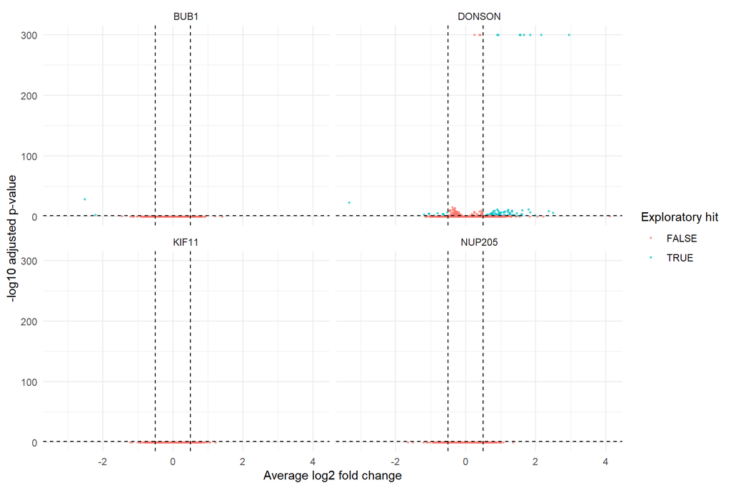

```r
ggplot(de, aes(avg_log2FC, -log10(pmax(p_val_adj, 1e-300)))) +
  geom_point(aes(color=significant), size=0.5, alpha=0.6) +
  facet_wrap(~perturbation) + geom_vline(xintercept=c(-0.5, 0.5), linetype=2) +
  geom_hline(yintercept=-log10(0.05), linetype=2) +
  labs(x="Average log2 fold change", y="-log10 adjusted p-value", color="Exploratory hit") + theme_minimal()
```

### Interpretation

The volcano panels show direction, effect size, and exploratory cell-level statistical ranking for four selected perturbations. DONSON has more genes beyond both plotted cutoffs than BUB1, KIF11, or NUP205. The panels do not establish a mechanism.

# Aggregate profiles and perturbation-level effects

The following sums raw counts across cells by label. Each label has one aggregate, so these are descriptive pseudobulk summaries without replicate-level variance estimates. Effect vectors are log2 CPM differences from the non-targeting aggregate.

```r
raw_counts <- GetAssayData(obj, assay="RNA", layer="counts")
groups <- c(CONTROL_LABEL, eligible)
pseudobulk <- sapply(groups, function(label) Matrix::rowSums(raw_counts[, obj$gene == label, drop=FALSE]))
colnames(pseudobulk) <- groups
cpm <- sweep(pseudobulk, 2, colSums(pseudobulk), "/") * 1e6
log_cpm <- log2(cpm + 1)
delta_all <- sweep(log_cpm[, eligible, drop=FALSE], 1, log_cpm[, CONTROL_LABEL], "-")
obj <- FindVariableFeatures(obj, nfeatures=2000, verbose=FALSE)
effect_genes <- intersect(VariableFeatures(obj), rownames(delta_all))
delta <- delta_all[effect_genes, , drop=FALSE]
magnitude <- data.frame(perturbation=colnames(delta), l2_effect=sqrt(colSums(delta^2))) |> arrange(desc(l2_effect))
print(magnitude)
```

```
##         perturbation l2_effect
## GAB2            GAB2 24.474163
## NCBP2          NCBP2 21.778418
## CHMP6          CHMP6 21.327754
## DONSON        DONSON 19.225358
## CPSF3          CPSF3 18.187568
## RRM2            RRM2 13.279746
## SLC39A9      SLC39A9 10.943578
## RPL3            RPL3 10.468673
## SNX15          SNX15 10.118925
## NUP205        NUP205  9.123775
## BUB1            BUB1  8.897328
## KIF11          KIF11  8.779880
```

```r
saveRDS(pseudobulk, "data/processed/03_pseudobulk_raw_counts.rds")
saveRDS(delta, "data/processed/03_perturbation_effect_matrix.rds")
write.csv(magnitude, "results/03_perturbation_magnitude.csv", row.names=FALSE)
```

### Interpretation

The raw-count sums form one aggregate perturbation expression profile per label, without replicate-level variance estimates. Log2 CPM differences from the shared non-targeting aggregate create perturbation-level effect vectors across 2,000 variable genes. Their L2 norms summarize response magnitude and can also reflect composition or technical differences.

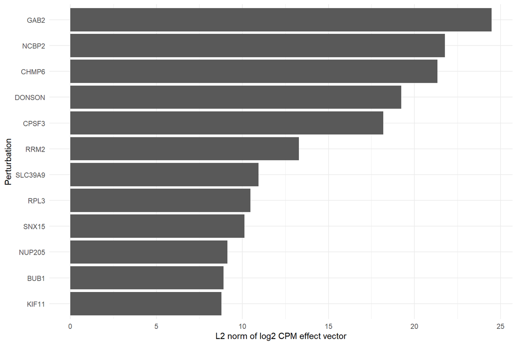

```r
ggplot(magnitude, aes(reorder(perturbation, l2_effect), l2_effect)) + geom_col() + coord_flip() +
  labs(x="Perturbation", y="L2 norm of log2 CPM effect vector") + theme_minimal()
```

### Key finding

GAB2 has the largest aggregate effect-vector norm (24.474) among the 12 analyzed targets. This is a descriptive measure of deviation from control across the selected genes, not a replicate-aware test. The ranking does not generalize to all targets in the source dataset.

# Distributional distance

`scperturbR` E-distance compares cell distributions in a 30-component PCA space. E-test permutes cell labels within the same experiment (199 permutations). Its p-values are exploratory because cells are not biological replicates.

```r
stopifnot(requireNamespace("scperturbR", quietly=TRUE))
obj <- ScaleData(obj, features=VariableFeatures(obj), verbose=FALSE)
obj <- RunPCA(obj, features=VariableFeatures(obj), npcs=30, verbose=FALSE)
e_matrix <- scperturbR::edist(obj, groupby="gene", reduction="pca", sample_correction=TRUE, verbose=FALSE)
e_control <- data.frame(perturbation=eligible,
                        e_distance_to_control=as.numeric(e_matrix[eligible, CONTROL_LABEL])) |>
  arrange(desc(e_distance_to_control))
print(e_control)
```

```
##    perturbation e_distance_to_control
## 1          GAB2           6.484480084
## 2         NCBP2           6.242540736
## 3         CPSF3           3.569811247
## 4         CHMP6           3.288906207
## 5        DONSON           2.845720017
## 6          RRM2           0.774736598
## 7       SLC39A9           0.316492518
## 8         SNX15           0.273549395
## 9          RPL3           0.144770139
## 10        KIF11           0.018233310
## 11       NUP205           0.007301823
## 12         BUB1           0.002933021
```

```r
e_test <- scperturbR::etest(obj, groupby="gene", control=CONTROL_LABEL,
                           reduction="pca", permutations=199, verbose=FALSE)
e_test <- e_test[eligible, , drop=FALSE] |>
  rownames_to_column("perturbation") |>
  arrange(pval)
print(e_test)
```

```
##    perturbation  pval      edist
## 1        DONSON 0.005  490.59551
## 2          RPL3 0.005   42.09304
## 3          GAB2 0.005 1087.88500
## 4          RRM2 0.005  149.14042
## 5         CHMP6 0.005  562.49562
## 6         NCBP2 0.005 1045.99639
## 7       SLC39A9 0.005   70.86754
## 8         SNX15 0.005   65.18292
## 9         CPSF3 0.005  603.57197
## 10        KIF11 0.195   22.33260
## 11         BUB1 0.335   19.53105
## 12       NUP205 0.345   19.94155
```

```r
write.csv(e_matrix, "results/03_scperturbR_E_distance_matrix.csv")
write.csv(e_control, "results/03_scperturbR_E_distance_to_control.csv", row.names=FALSE)
write.csv(e_test, "results/03_scperturbR_E_test.csv", row.names=FALSE)
```

### Key finding

GAB2 has the largest E-distance from non-targeting cells (6.484), indicating the greatest multivariate separation in the 30-component PCA representation among these targets. E-tests used 199 cell-label permutations. Their p-values remain exploratory and do not provide biological-replicate-aware inference or establish a causal mechanism.

```r
saveRDS(obj, "data/processed/03_k562_perturbation_ready.rds")
```

## Key results

```r
cat("Eligible targets:", length(eligible), "control cells:", cell_counts$n_cells[cell_counts$perturbation == CONTROL_LABEL], "\n")
```

```
## Eligible targets: 12 control cells: 493
```

```r
cat("Largest negative target-expression difference:", kd$target[1], round(kd$delta_mean_log[1], 3), "\n")
```

```
## Largest negative target-expression difference: RPL3 -0.438
```

```r
cat("Largest aggregate response:", magnitude$perturbation[1], round(magnitude$l2_effect[1], 3), "\n")
```

```
## Largest aggregate response: GAB2 24.474
```

```r
cat("Largest E-distance to control:", e_control$perturbation[1], round(e_control$e_distance_to_control[1], 3), "\n")
```

```
## Largest E-distance to control: GAB2 6.484
```

```r
print(de_summary)
```

```
## # A tibble: 4 x 3
##   perturbation n_tested n_exploratory_hits
##   <chr>           <int>              <int>
## 1 BUB1             8563                  2
## 2 DONSON           8563                 94
## 3 KIF11            8563                  0
## 4 NUP205           8563                  0
```

- Focused cohort: 12 targets with 245–249 cells each and 493 controls support detailed exploratory comparisons.
- Target expression: RPL3 has the largest negative mean log-normalized difference (−0.438), consistent with reduced target transcript abundance.
- Cell-level DE: DONSON has 94 exploratory hits and BUB1 has 2; these are not replicate-aware findings.
- Aggregate response: GAB2 has the largest effect-vector norm (24.474) across 2,000 variable genes.
- Distributional response: GAB2 has the largest E-distance from control (6.484); the 199-permutation E-tests remain exploratory.